# Informe análisis de escalas PACES

Fondecyt n°1181239

2021-08-02

# Introducción

El presente documento expone un análisis de validez con la intención de disminuir la cantidad de ítems por baterías de preguntas. Se busco eliminar aquellas variables que permitieran mantener o mejorar las propiedades psicométricas de las escalas.

El documento esta estructurado según escalas, siendo cada una sección seleccionable en la barra de la izquierda. Dentro de cada sección se propone un conjunto de variables a eliminar, señalando las razones y el modelo propuesto. Además, en las pestañas se pueden observar descriptivos y correlaciones.

# Igualdad de derechos para grupos étnicos

> Propongo dos opciones: de las 5 variables, se mantienen 3 en la primera opción y 4 en la segunda. Con tres variables no alcanza para hacer un factor por sí mismas, ya que faltan grados de libertad, no obstante, podría servir para modelos con más parámetros. Además, dejar 4 implica solo eliminar una, por lo que no ayuda a reducir la encuesta.

**Variables incluidas en todos los modelos**

- P16A los grupos étnicos deberían tener la misma oportunidad de acceder a una buena educación
- P16B los grupos étnicos deberían tener la misma oportunidad de conseguir buenos trabajos
- P16E Los miembros de todos los grupos étnicos deberían tener los mismos derechos y responsabilidades

**Variable incluida en un modelo**

- P16C Las escuelas deberían enseñar a los estudiantes a respetar a los miembros de todos los grupos étnicos Variable eliminada:

**Variable excluida** *comentario*: Si bien presenta más varianza y es interesante que los estudiantes no estén de acuerdo con eso, posee una menor relación con las otras variables, por lo que los modelos ajustan mejor sin ella.

- P16D Debería promoverse que miembros de todos los grupos étnicos se presentarán a las elecciones para cargos políticos.

## Modelos de medida

Comparación entre modelos

| Utilizando variables como | N | Estimador | chi2 | df | p-value | CFI | TLI | RMSEA | SRMR | Chi2/df |
| --- | --- | --- | --- | --- | --- | --- | --- | --- | --- | --- |
| Todas las variables | 1531 | DWLS | 24.106 | 5 | 0.000 | 1 | 0.999 | 0.050 | 0.023 | 4.821 |
| Tres indicadores | 1531 | DWLS | 0.000 | 0 | NA | 1 | 1.000 | 0.000 | 0.000 | Inf |
| Cuatro indicadores | 1531 | DWLS | 5.355 | 2 | 0.069 | 1 | 1.000 | 0.033 | 0.009 | 2.677 |

> Modelo reducido (Tres indicadores)

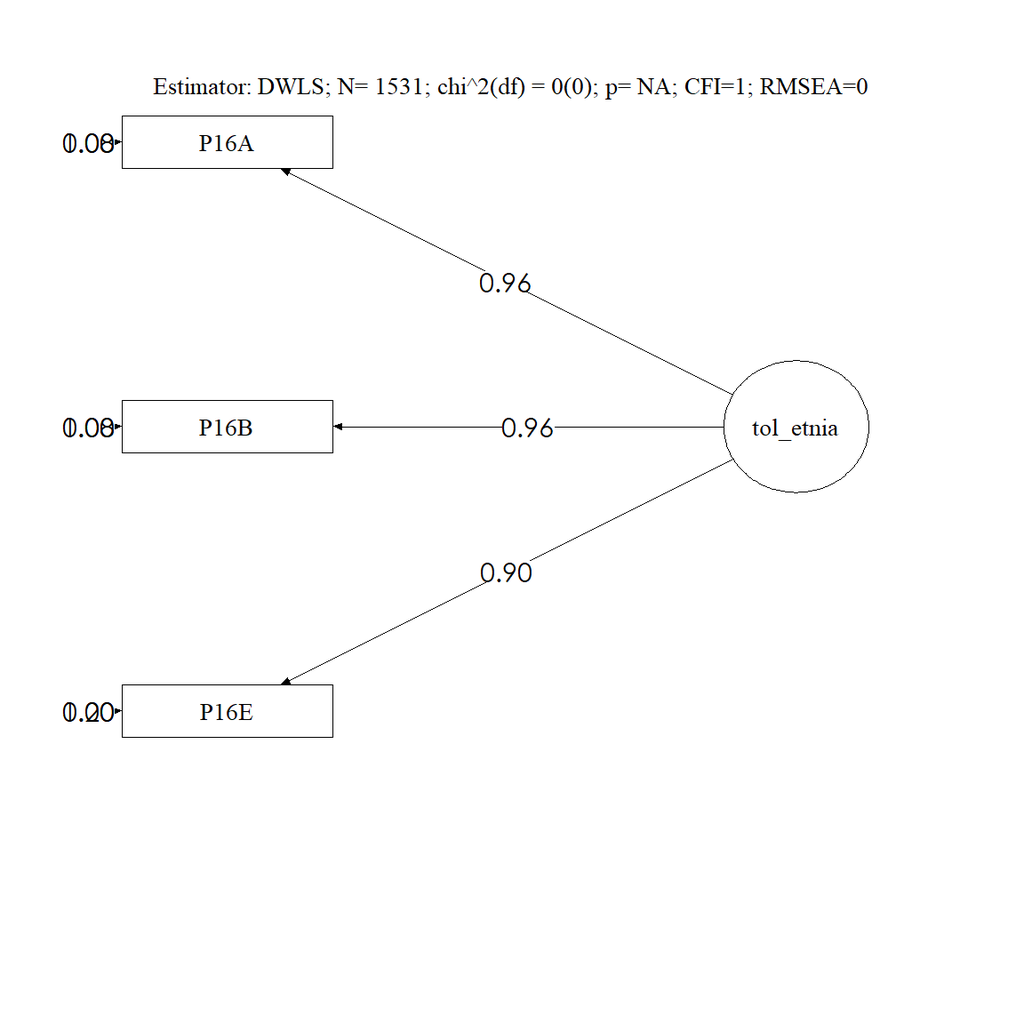

> Modelo reducido 1 (Cuatro indicadores)

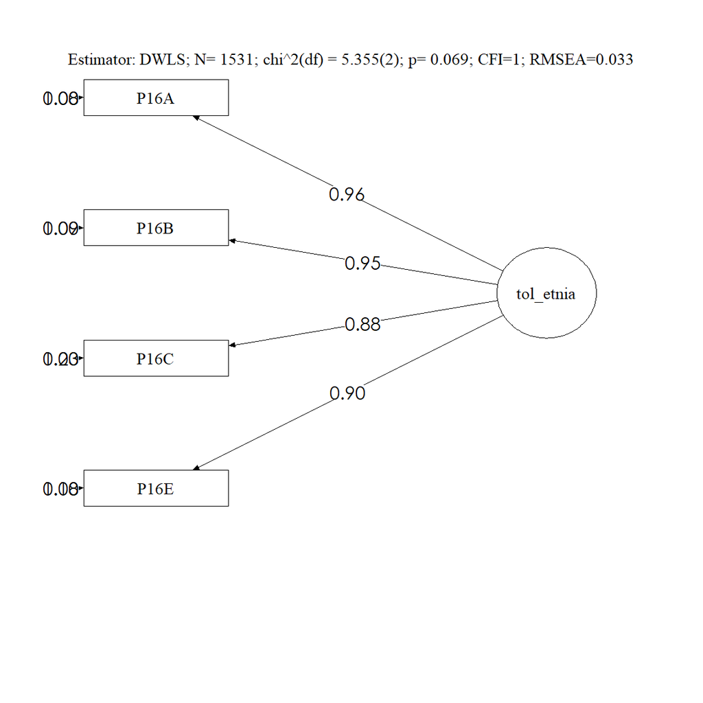

> Modelo completo

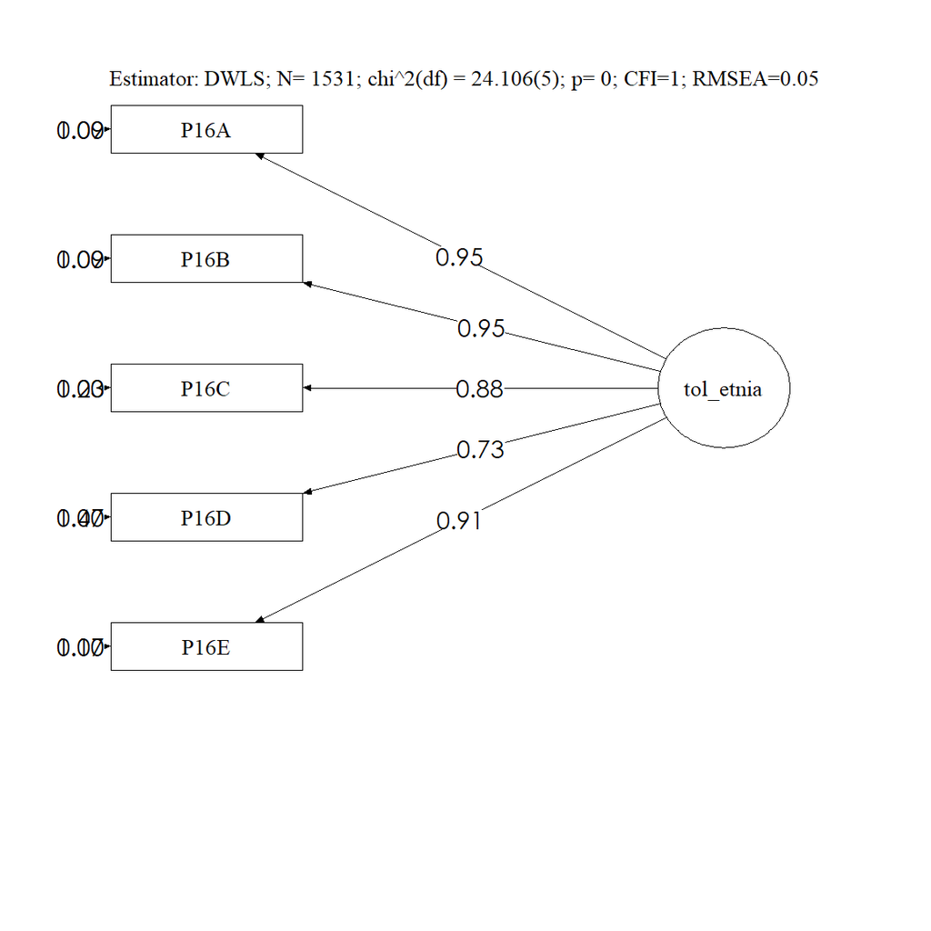

## Descriptivos

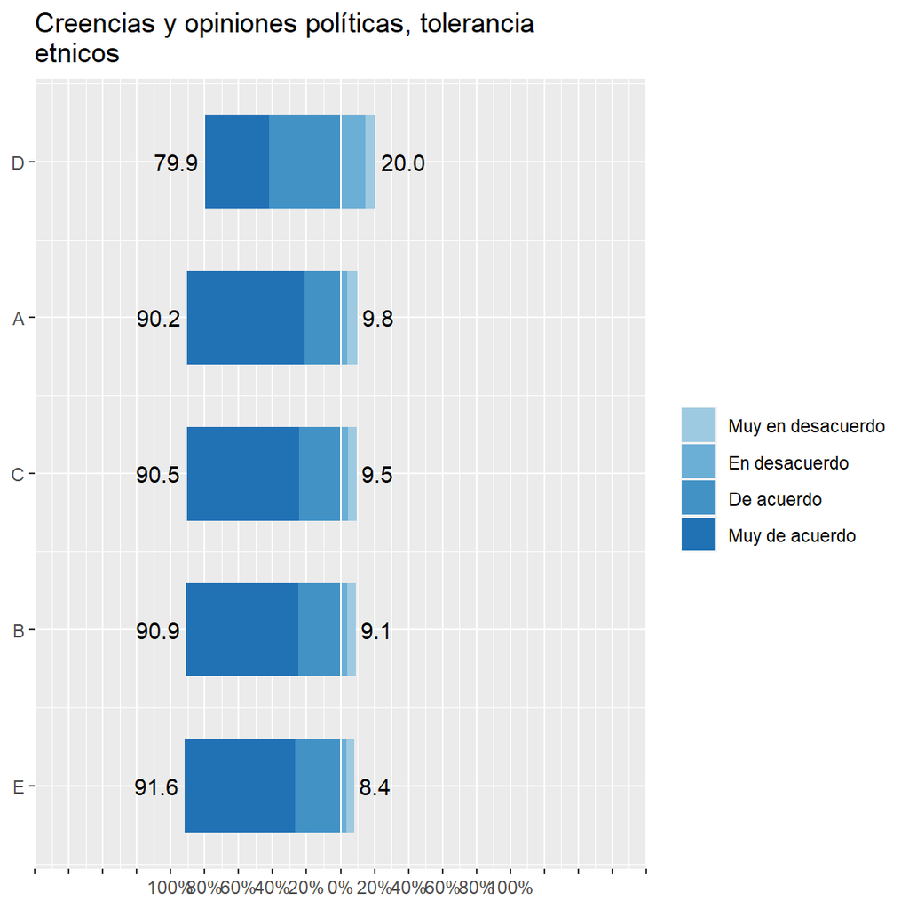

- La variable D si bien posee más variación, es curioso que genere una respuesta tan distinta a las demás. Parece estar incorporando otras dimensiones más allá de la igualdad de derechos. Quizás porque es una “promoción”, lo que va más allá de una declaración de igualdad de derechos.

## Correlaciones

**Igualdad de derechos para grupos etnicos**

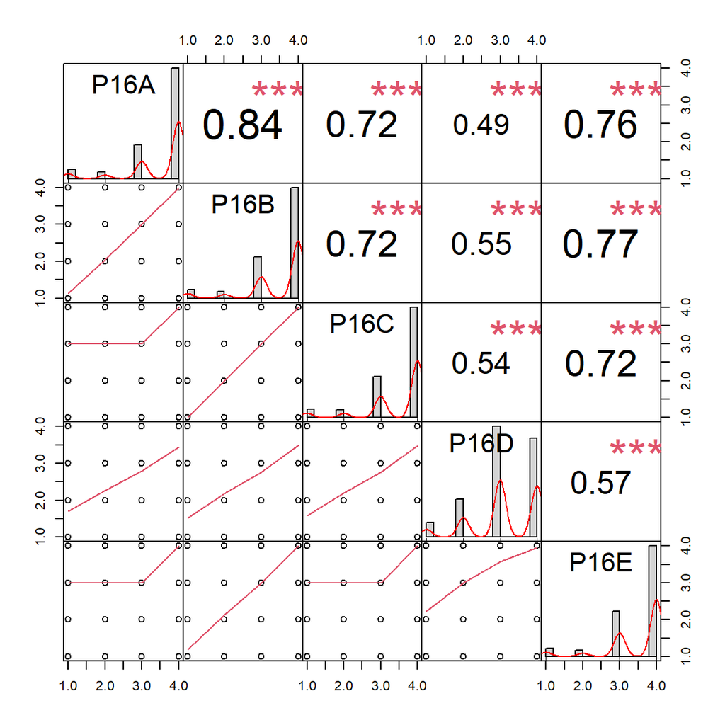

# Creencias del buen ciudadano

> Considerando la varianza, las cargas cruzadas y su relación con el factor considero mantener 9 de las 16 variables, en consideración de un modelo de tres dimensiones.

**Variables seleccionadas**

Buen ciudadano como obediencia civil:

- P17E: Demostrar respeto por los representantes de los gobiernos en general
- P17K: Obedecer siempre la ley
- P17N: Siempre pagar los impuestos

Buen ciudadano como participante activo-comunitario:

- P17H: Participar en actividades para beneficiar a la gente de su comunidad
- P17I: Participar en actividades que promuevan los derechos humanos
- P17J: Participar en actividades para la protección del medio ambiente

Buen ciudadano como participante institucional:

- P17A: Votar en todas las elecciones presidenciales
- P17F: Conversar sobre política
- P17P: Preocuparse de que las autoridades públicas actúen correctamente

**Variables eliminadas:**

```
* P17B: Unirse a un partido político
```

- P17C: Aprender de la historia del país
- P17D: Seguir los temas políticos en el diario, la radio, la televisión o Internet
- P17G: Participar en protestas pacíficas en contra de las leyes que considera injustas
- P17L: Respetar el derecho de otros a tener su propia opinión
- P17M: Apoyar a personas en peor situación económica que uno
- P17O: Apoyar a personas en peor situación económica que uno

## Modelos de medida

Comperación entre modelos

| Modelo | $N$ | Estimador | $\chi^2$ | df | p-value | CFI | TLI | RMSEA | SRMR | $\chi2$/df |
| --- | --- | --- | --- | --- | --- | --- | --- | --- | --- | --- |
| Todas las variables | 1470 | DWLS | 2303.858 | 103 | 0 | 0.909 | 0.894 | 0.121 | 0.109 | 22.368 |
| Bateria recortada | 1470 | DWLS | 64.981 | 24 | 0 | 0.996 | 0.994 | 0.034 | 0.033 | 2.708 |

> Modelo reducido

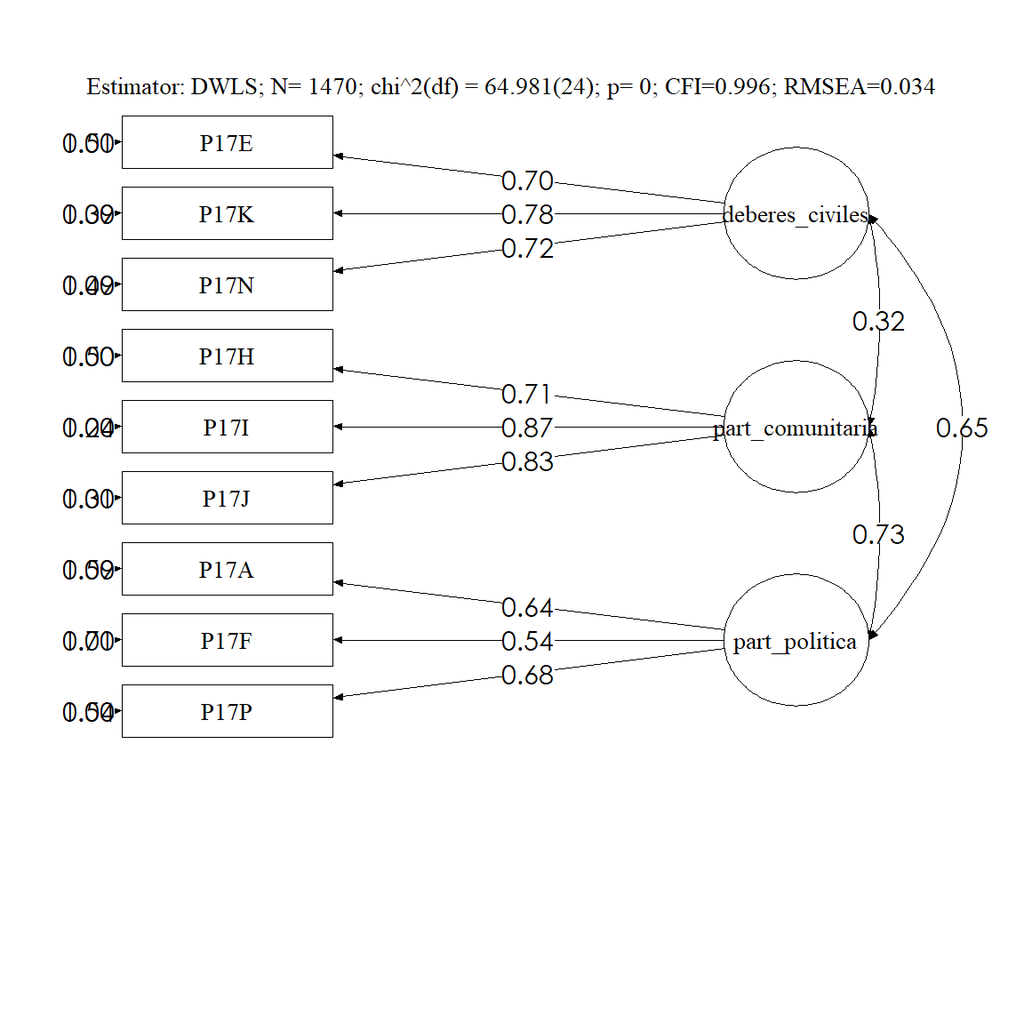

> Modelo completo

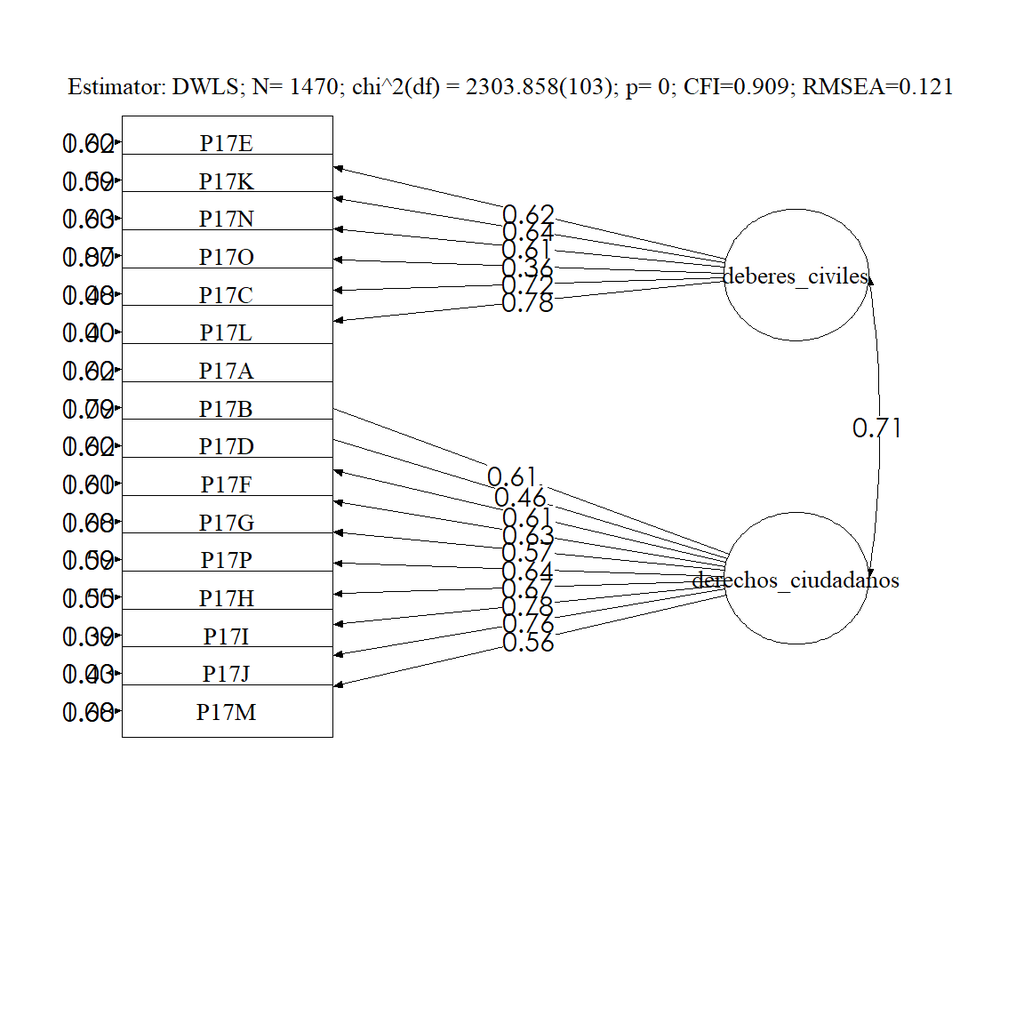

## Descriptivos

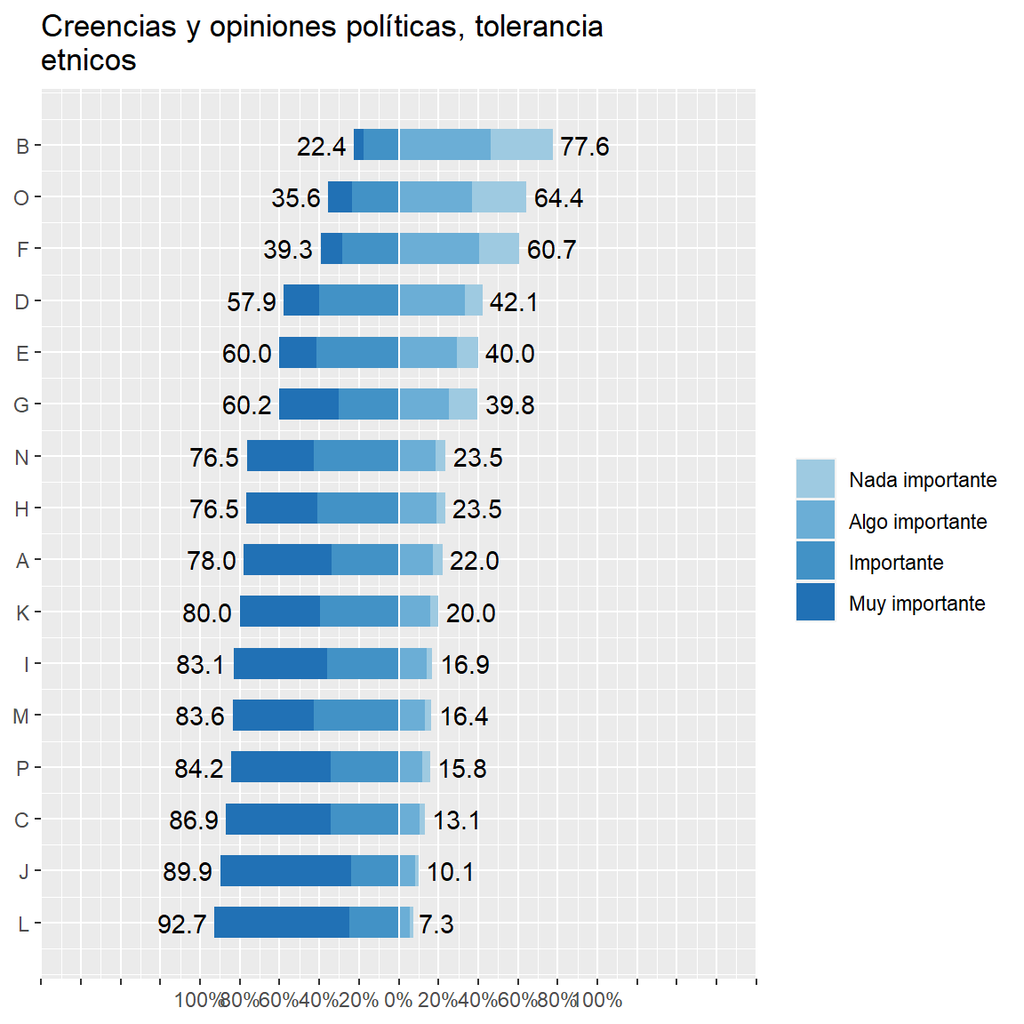

La variable L debe ser eliminada por estar muy concentrada

## Correlaciones

**Variables seleccionadas**

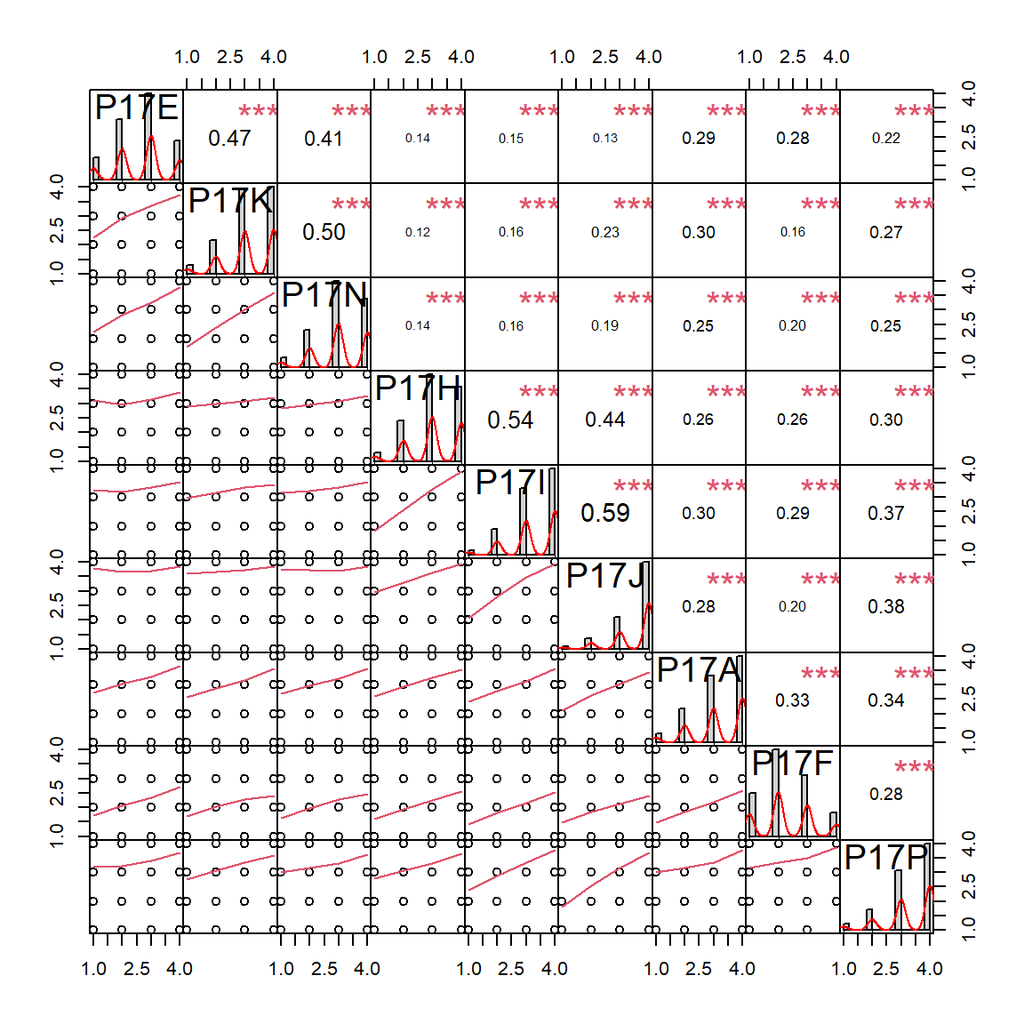

**Variables no seleccionadas**

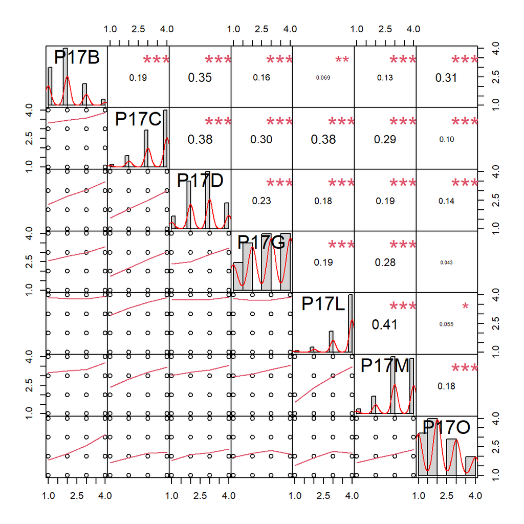

```r
varnoseleccionadas = est_proc_buenci %>% select(
  P17B,
  P17C,
  P17D,
  P17G,
  P17L,
  P17M,
  P17O)

chart.Correlation(varnoseleccionadas, histogram = TRUE, method = "pearson")
```

# Igualdad de derechos entre hombres y mujeres

> Existen varias opciones. Sugiero quedarnos con un modelo de cuatro indicadores en dos dimensiones (publico-privado), que responde a la teoría, disminuye más indicadores y tiene mejor ajuste. Los modelos con 3 dimensiones y 6 ítem o con 2 dimensiones y 6 ítems no permiten reducir considerablemente la batería. El modelo de una dimensión tiene igualmente 4 ítems, pero es menos especifico y no responde a una división teórica importante en el tema (espacio público/privado)

Igualdad de género en espacio publico

- P18C: Las mujeres deberían permanecer alejadas de la política
- P18D: Cuando no hay muchos trabajos disponibles, los hombres deberían tener más derecho a un trabajo que las mujeres

Igualdad de género en espacio privado

- P18B: La primera prioridad de las mujeres debería ser criar hijos
- P18H: El rol más importante de una mujer es cuidar su hogar y cocinar para su familia

Variables eliminadas:

- P18E: Los hombres y las mujeres deberían recibir el mismo pago cuando hacen los mismos trabajos
- P18G: Los hombres y las mujeres deberían recibir el mismo pago cuando hacen los mismos trabajos
- P18A Los hombres y las mujeres deberían tener las mismas oportunidades de participar en el gobierno
- P18F Los hombres están mejor preparados para ser líderes políticos que las mujeres
- P18I Un hombre debe tener la última palabra sobre las decisiones del hogar

## Modelos de medida

Comperación entre modelos

| Modelo | $N$ | Estimador | $\chi^2$ | df | p-value | CFI | TLI | RMSEA | SRMR | $\chi2$/df |
| --- | --- | --- | --- | --- | --- | --- | --- | --- | --- | --- |
| Todas las variables | 1524 | DWLS | 78.951 | 24 | 0.000 | 0.999 | 0.998 | 0.039 | 0.028 | 3.290 |
| 2 item por 3 dimensiones | 1536 | DWLS | 3.918 | 6 | 0.688 | 1.000 | 1.000 | 0.000 | 0.011 | 0.653 |
| 2 item por 2 dimensiones | 1551 | DWLS | 0.042 | 1 | 0.838 | 1.000 | 1.000 | 0.000 | 0.001 | 0.042 |
| 4 item en 1 dimensiones | 1568 | DWLS | 1.166 | 2 | 0.558 | 1.000 | 1.000 | 0.000 | 0.007 | 0.583 |

> “2 item por 3 dimensiones”

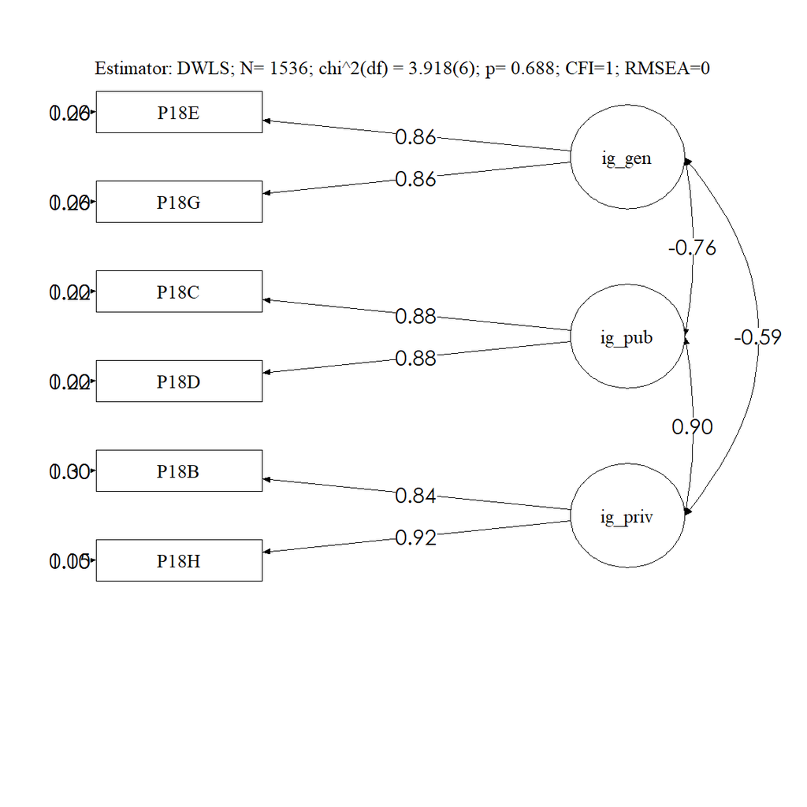

> “2 item por 2 dimensiones”

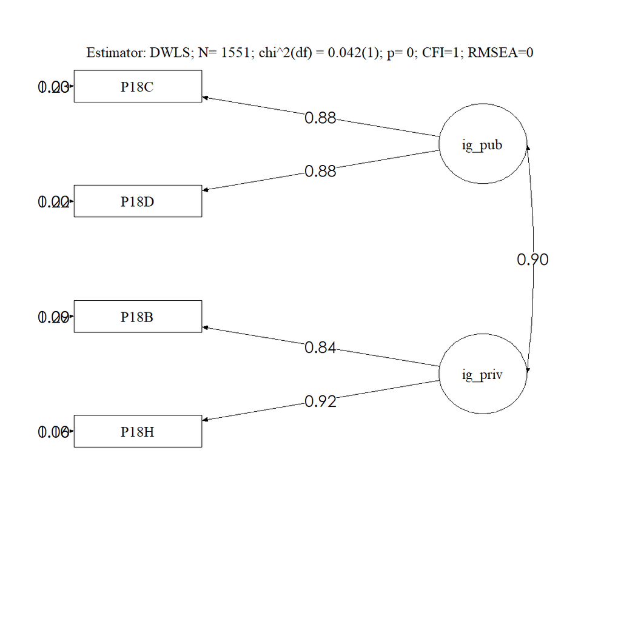

> “4 item en una dimensión”

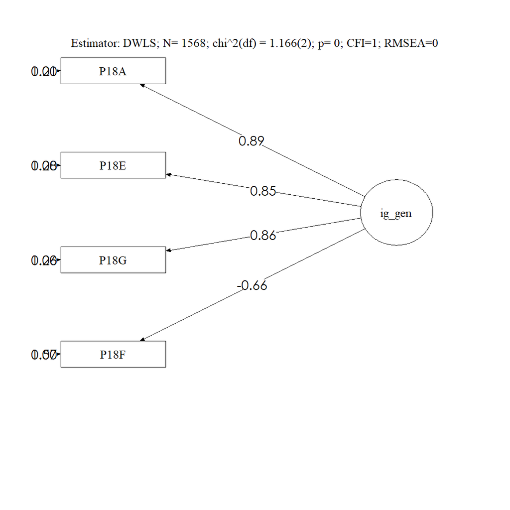

> Modelo completo

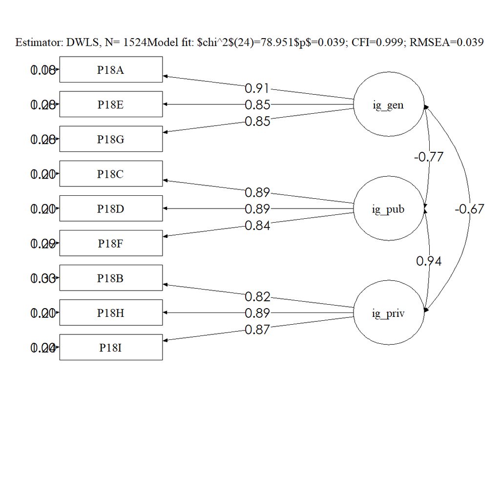

## Descriptivos

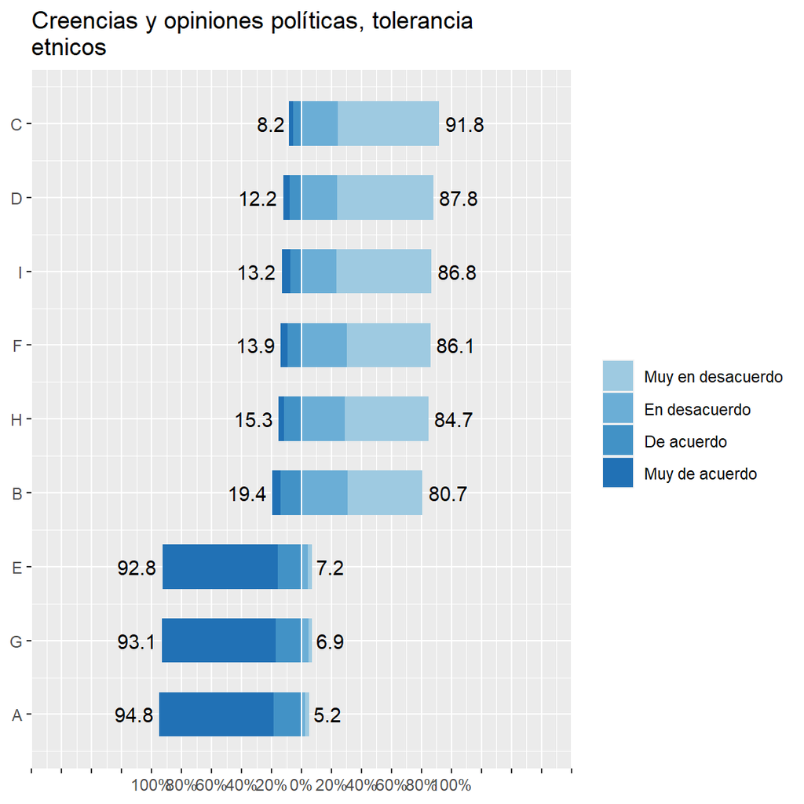

> a 5%, g 7%, e 7%. La de igualdad de genero

## Correlaciones

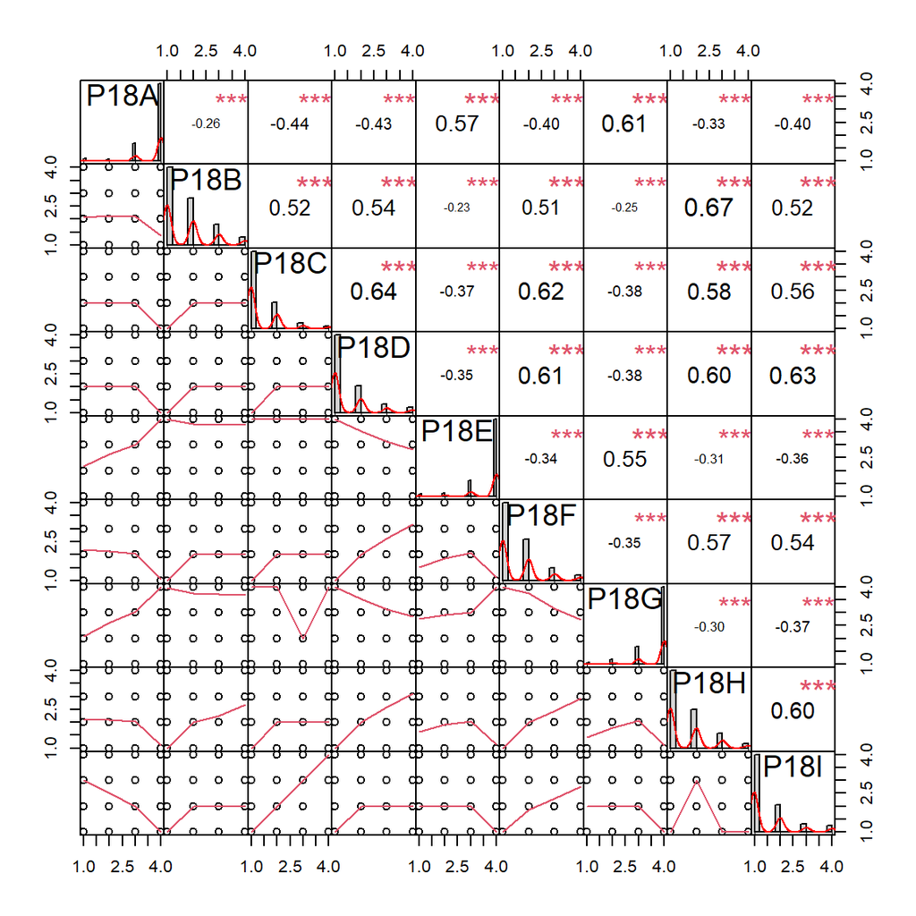

# Igualdad de derechos para inmigrantes

> Se propone utilizar un modelo de una dimensión y cuatro indicadores. Con esto se reduce la batería desde 8 preguntas a 4. El modelo elegido es el con mejor ajuste.
- P19B: Los hijos y las hijas de inmigrantes deberían tener las mismas oportunidades de educación que los otros niños y niñas del país
- P19D: Los inmigrantes deberían tener la oportunidad de continuar con sus costumbres y estilo de vida
- P19C: Los inmigrantes que han vivido en un país por varios años deberían poder votar en las elecciones
- P19E: Los inmigrantes deberían tener los mismos derechos que el resto de los habitantes del país

Eliminadas

- P19A: Los inmigrantes deberían tener la oportunidad de seguir hablando su idioma
- P19H: Los inmigrantes tienen costumbres y tradiciones que no se ajustan con la sociedad chilena
- P19F: Cuando no hay suficientes trabajos disponibles, se debería restringir la inmigración
- P19G: Los inmigrantes frecuentemente ocupan los puestos de trabajos de los chilenos

## Modelos de medida

Comperación entre modelos

| Utilizando variables como | $N$ | Estimador | $\chi^2$ | $\chi2$/df | p-value | CFI | TLI | RMSEA | SRMR |
| --- | --- | --- | --- | --- | --- | --- | --- | --- | --- |
| Todas las variables | 1527 | DWLS | 782.557 | 46.033 | 0.000 | 0.951 | 0.920 | 0.172 | 0.101 |
| 3 dimensiones 6 items | 1527 | DWLS | 466.354 | 77.726 | 0.000 | 0.899 | 0.748 | 0.224 | 0.115 |
| 1 dimensión 4 items | 1527 | DWLS | 8.284 | 4.142 | 0.016 | 0.999 | 0.998 | 0.045 | 0.017 |

> Modelo reducido de 4 items en 1 dimension

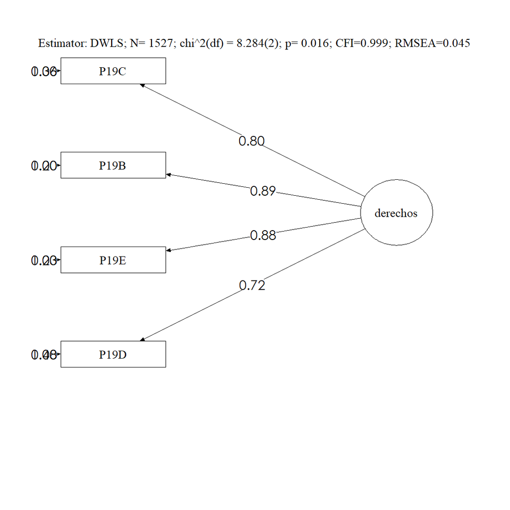

> Modelo reducido de 6 items en 3 dimensiones

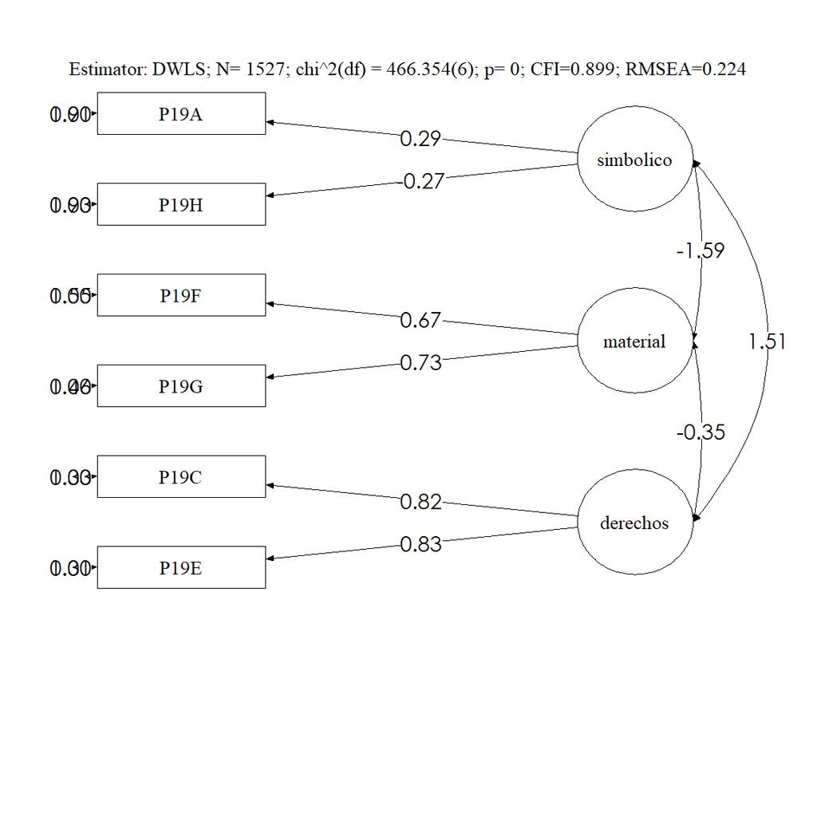

> Modelo completo

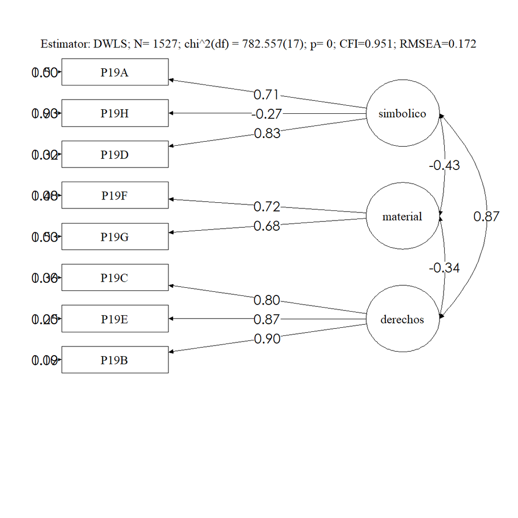

## Descriptivos

Data frame: est_proc_inmigrantes

| ID | Name | Type | Label | Values | Value Labels | Freq. |
| --- | --- | --- | --- | --- | --- | --- |
| 1 | P19A | numeric | P19A ¿Cuán de acuerdo o en desacuerdo estás con las siguientes afirmaciones sobr | 1 2 3 4 | Muy en desacuerdo En desacuerdo De acuerdo Muy de acuerdo | 102 249 790 386 |
| 2 | P19B | numeric | P19B ¿Cuán de acuerdo o en desacuerdo estás con las siguientes afirmaciones sobr | 1 2 3 4 | Muy en desacuerdo En desacuerdo De acuerdo Muy de acuerdo | 44 81 473 929 |
| 3 | P19C | numeric | P19C ¿Cuán de acuerdo o en desacuerdo estás con las siguientes afirmaciones sobr | 1 2 3 4 | Muy en desacuerdo En desacuerdo De acuerdo Muy de acuerdo | 77 170 641 639 |
| 4 | P19D | numeric | P19D ¿Cuán de acuerdo o en desacuerdo estás con las siguientes afirmaciones sobr | 1 2 3 4 | Muy en desacuerdo En desacuerdo De acuerdo Muy de acuerdo | 84 225 714 504 |
| 5 | P19E | numeric | P19E ¿Cuán de acuerdo o en desacuerdo estás con las siguientes afirmaciones sobr | 1 2 3 4 | Muy en desacuerdo En desacuerdo De acuerdo Muy de acuerdo | 58 124 517 828 |
| 6 | P19F | numeric | P19F ¿Cuán de acuerdo o en desacuerdo estás con las siguientes afirmaciones sobr | 1 2 3 4 | Muy en desacuerdo En desacuerdo De acuerdo Muy de acuerdo | 289 533 468 237 |
| 7 | P19G | numeric | P19G ¿Cuán de acuerdo o en desacuerdo estás con las siguientes afirmaciones sobr | 1 2 3 4 | Muy en desacuerdo En desacuerdo De acuerdo Muy de acuerdo | 294 496 542 195 |
| 8 | P19H | numeric | P19H ¿Cuán de acuerdo o en desacuerdo estás con las siguientes afirmaciones sobr | 1 2 3 4 | Muy en desacuerdo En desacuerdo De acuerdo Muy de acuerdo | 194 549 602 182 |

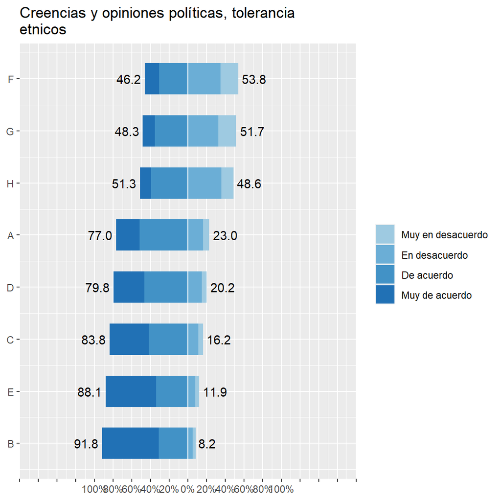

## correlaciones

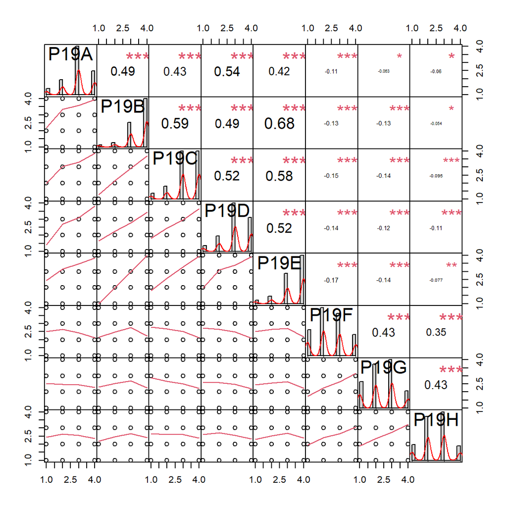

# Autoritarismo

> Se eliminan 5 variables y se mantienen 4 distribuidas en dos dimensiones.

Justificación dictaduras

- P21H: Los gobiernos autoritarios se justifican cuando traen orden y seguridad
- P21I: Los gobiernos autoritarios se justifican cuando traen beneficios económicos

Autoritarismo

- P21E: Los gobernantes deben hacer valer su autoridad
- P21G: La concentración del poder ayuda a mantener el orden

Variables no seleccionadas

- P21A: Los jóvenes deben aprender a obedecer y respetar a las autoridades
- P21B: Mientras más personas estén dispuestas a criticar y desafiar a las autoridades es mejor para la sociedad
- P21C: La tolerancia con ideas distintas es uno de los valores más importantes que los jóvenes debieran aprender
- P21D: A veces es mejor que los gobernantes tomen decisiones sin consultar a las mayorías
- P21F: Los gobernantes pierden autoridad cuando reconocen sus errores

```r
load(file="../input/data/original.RData")

pacman::p_load(dplyr, sjmisc, car, sjlabelled, stargazer, SciViews, summarytools, misty,sjPlot,PerformanceAnalytics,ggplot2,lavaan,stats, semPlot)

# Seleccionar y renombrar variables de la base de datos de estudiantes.
est_proc_autoritarismo <- est  %>% dplyr::select(starts_with("P21"))

est_proc_autoritarismo <- set_na(est_proc_autoritarismo, na = c(5,9), drop.levels = TRUE, as.tag = FALSE) # Transformar a NA

est_proc_autoritarismo =na.omit(est_proc_autoritarismo)
```

## Modelos

```r
# Exploratorio

factanal(est_proc_autoritarismo, factors = 1, rotation = "none")

# El análisis exploratorio indica que no hay dimensiones, cuando se agregan las variables tienden a tener un tercio de carga en cada factor-

# Cuando se utiliza un solo factor no se incluyen las variables P21B y c.

# Las únicas variables que poseen una relación alta entre si son las dos más conocidas del concepto H e I y la G que capta bien la idea de autoritarismo.

#

# AFC: Modelo con todos los indicadores



modeloautoritario1 =  ' autoritarismo =~ P21A + P21B + P21C + P21D +  P21E + P21F + P21G + P21H + P21I'

fit1 <- cfa(modeloautoritario1, data=est_proc_autoritarismo, estimator="DWLS", ordered = T)

#summary(fit1, fit.measures=TRUE)

#semPaths(fit1, what = "stand")

# AFC: Modelo con indicadores reducidos

modeloautoritario2 =  ' autoritarismo_oportuno =~ P21H + P21I
                        autoritarismo=~ P21E + P21G '

fit2 <- cfa(modeloautoritario2, data=est_proc_autoritarismo, estimator="DWLS", ordered = T)

#summary(fit2, fit.measures=TRUE)

#semPaths(fit2, what = "stand")

#modificationindices(fit2)
```

```r
#-----------------------------------------------------------------------------------------##
pacman::p_load(dplyr, kableExtra, knitr)

# extract fit indices from models and add to table
sum_fit1<- dplyr::bind_rows(fitmeasures(fit1)[c("chisq","df","pvalue","cfi","tli","rmsea","srmr")],
                    fitmeasures(fit2)[c("chisq","df","pvalue","cfi","tli","rmsea","srmr")])

# Customize object
sum_fit1$mod <- c("Todas las variables","Bateria recortada")
sum_fit1$nobs <- c(nobs(fit1),nobs(fit2))
sum_fit1$est <- c("DWLS","DWLS")
sum_fit1$df_ch<-c(sum_fit1$chisq/sum_fit1$df)
sum_fit1 <- dplyr::select(sum_fit1,mod,nobs,est,everything())
colnames <- c("Modelo","$N$","Estimador","$\\chi^2$","df","p-value","CFI","TLI","RMSEA","SRMR","$\\chi2$/df")

# Create table
table_cfa_fits1 <-kable(sum_fit1, format="pandoc", digits=3, booktabs=T, col.names=colnames,  caption = "Comperación entre modelos", escape = FALSE) %>% kable_styling(full_width = F, font_size = 14)
table_cfa_fits1
```

Comperación entre modelos

| Modelo | $N$ | Estimador | $\chi^2$ | df | p-value | CFI | TLI | RMSEA | SRMR | $\chi2$/df |
| --- | --- | --- | --- | --- | --- | --- | --- | --- | --- | --- |
| Todas las variables | 1432 | DWLS | 913.929 | 27 | 0.000 | 0.941 | 0.921 | 0.152 | 0.11 | 33.849 |
| Bateria recortada | 1432 | DWLS | 0.000 | 1 | 0.995 | 1.000 | 1.001 | 0.000 | 0.00 | 0.000 |

> Modelo reducido

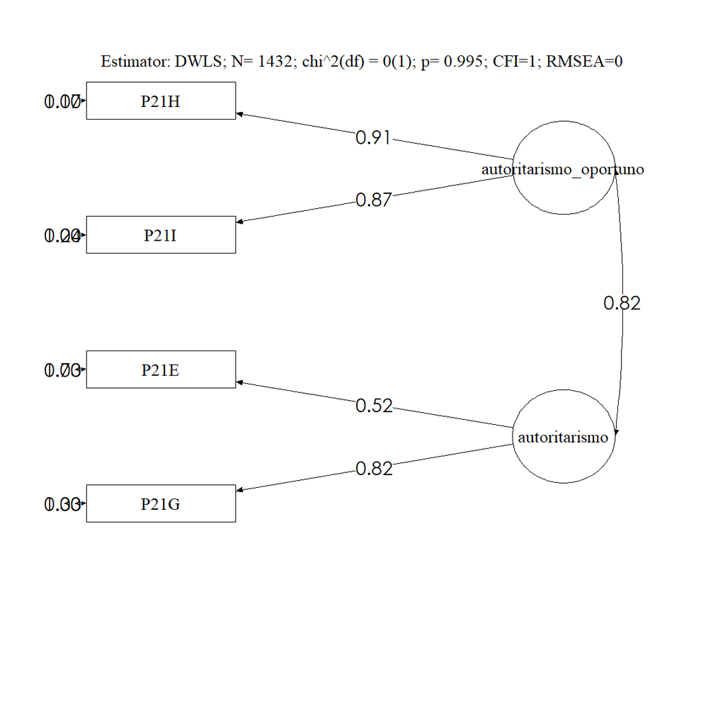

> Modelo completo

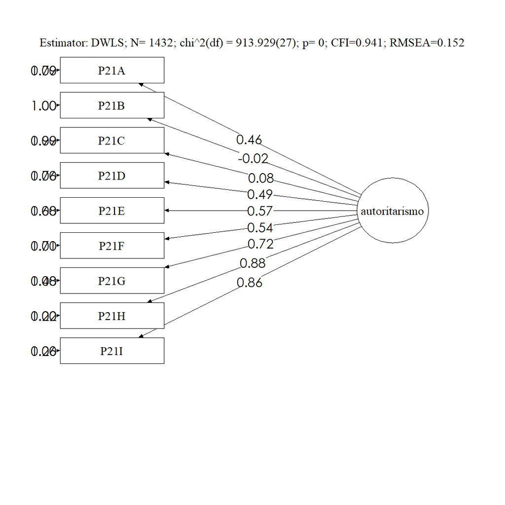

## Descriptivo

```r
#Descriptivos

sjPlot::view_df(est_proc_autoritarismo, show.type = T, show.frq = T) # Cambiar por dfsummary
```

Data frame: est_proc_autoritarismo

| ID | Name | Type | Label | Values | Value Labels | Freq. |
| --- | --- | --- | --- | --- | --- | --- |
| 1 | P21A | numeric | P21A ¿Qué tan de acuerdo o en desacuerdo estás con las siguientes afirmaciones s | 1 2 3 4 | Muy en desacuerdo En desacuerdo De acuerdo Muy de acuerdo | 99 189 797 347 |
| 2 | P21B | numeric | P21B ¿Qué tan de acuerdo o en desacuerdo estás con las siguientes afirmaciones s | 1 2 3 4 | Muy en desacuerdo En desacuerdo De acuerdo Muy de acuerdo | 192 653 426 161 |
| 3 | P21C | numeric | P21C ¿Qué tan de acuerdo o en desacuerdo estás con las siguientes afirmaciones s | 1 2 3 4 | Muy en desacuerdo En desacuerdo De acuerdo Muy de acuerdo | 34 115 676 607 |
| 4 | P21D | numeric | P21D ¿Qué tan de acuerdo o en desacuerdo estás con las siguientes afirmaciones s | 1 2 3 4 | Muy en desacuerdo En desacuerdo De acuerdo Muy de acuerdo | 721 418 218 75 |
| 5 | P21E | numeric | P21E ¿Qué tan de acuerdo o en desacuerdo estás con las siguientes afirmaciones s | 1 2 3 4 | Muy en desacuerdo En desacuerdo De acuerdo Muy de acuerdo | 157 355 765 155 |
| 6 | P21F | numeric | P21F ¿Qué tan de acuerdo o en desacuerdo estás con las siguientes afirmaciones s | 1 2 3 4 | Muy en desacuerdo En desacuerdo De acuerdo Muy de acuerdo | 439 553 321 119 |
| 7 | P21G | numeric | P21G ¿Qué tan de acuerdo o en desacuerdo estás con las siguientes afirmaciones s | 1 2 3 4 | Muy en desacuerdo En desacuerdo De acuerdo Muy de acuerdo | 310 435 541 146 |
| 8 | P21H | numeric | P21H ¿Qué tan de acuerdo o en desacuerdo estás con las siguientes afirmaciones s | 1 2 3 4 | Muy en desacuerdo En desacuerdo De acuerdo Muy de acuerdo | 242 365 650 175 |
| 9 | P21I | numeric | P21I ¿Qué tan de acuerdo o en desacuerdo estás con las siguientes afirmaciones s | 1 2 3 4 | Muy en desacuerdo En desacuerdo De acuerdo Muy de acuerdo | 216 362 671 183 |

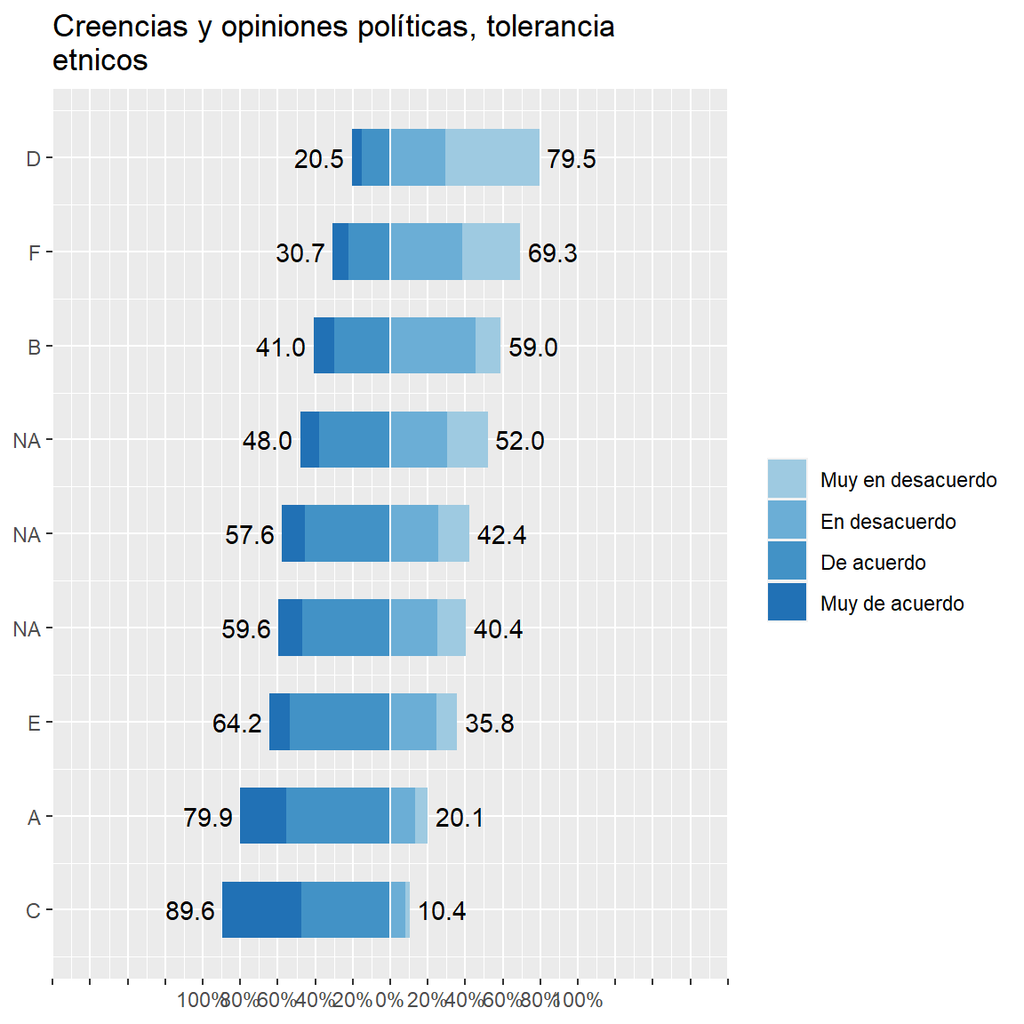

```r
items <- c("A", "B","C","D","E", "F")

# cambiar orden para la leyenda
labels= c("Muy en desacuerdo",
"En desacuerdo",
"De acuerdo",
"Muy de acuerdo")


sjPlot::plot_likert(est_proc_autoritarismo,
                         axis.labels   = items,
                         legend.labels = labels,
                         legend.pos = "bottom",
                         #cat.neutral   = , # identifica a indiferentes
                         geom.colors   = c("#9ECAE1", "#6BAED6", "#4292C6",
                                           "#2171B5"), # colorbrewer2.org
                         sort.frq      = "neg.asc", # sort descending)
                         title         = "Creencias y opiniones políticas, tolerancia etnicos",
                         intercept.line.color = "white", # vertical middle
                         expand.grid   = F, # no inner margins in plot
                         show.n        = FALSE, # hide N's in axis labels
                         grid.range    = 1.8,
                         geom.size = 0.6, values = "sum.outside")
```

## Correlaciones

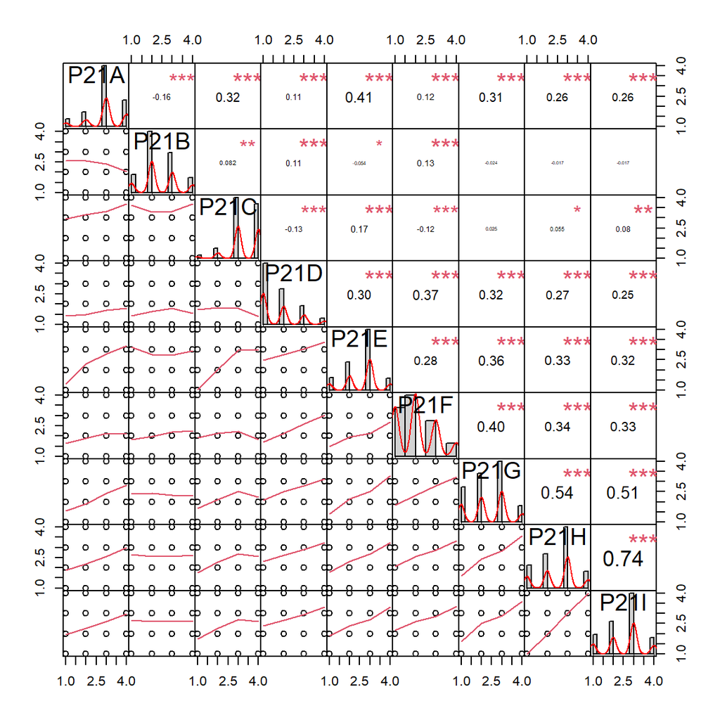

```r
# correlaciones

chart.Correlation(est_proc_autoritarismo, histogram = TRUE, method = "pearson")
```

```r
# La variable P21B  y P21C no correlaciona bien con las demás.

#-----------------------------------------------------------------------------------------##
```

# Legitimidad de la desigualdad

> Concuerdo con que sería bueno recuperar las variables a, b, e y f. Estas pueden formar dos factores. Son relevantes tanto por la contingencia como por su aplicación en otros contextos lo cual hace más fácil dialogar con otra literatura.

```r
load(file="../input/data/original.RData")

pacman::p_load(dplyr, sjmisc, car, sjlabelled, stargazer, SciViews, summarytools, misty,sjPlot,PerformanceAnalytics,ggplot2,lavaan,stats, semPlot)

# Seleccionar y renombrar variables de la base de datos de estudiantes.
est_proc_legdesigual<- est  %>% dplyr::select(starts_with("P25"))

est_proc_legdesigual <- set_na(est_proc_legdesigual, na = c(5,9), drop.levels = TRUE, as.tag = FALSE) # Transformar a NA

est_proc_legdesigual =na.omit(est_proc_legdesigual)
```

## Modelos

```r
# Exploratorio

factanal(est_proc_legdesigual, factors = 1, rotation = "none")



modeloautoritario1 =  ' jus_des =~ P25A + P25B + P25E + P25F'

fit1 <- cfa(modeloautoritario1, data=est_proc_legdesigual, estimator="DWLS", ordered = T)

#summary(fit1, fit.measures=TRUE)

#semPaths(fit1, what = "stand")

# AFC: Modelo con indicadores reducidos

modeloautoritario2 =  ' jus_des_ec =~ P25A + P25B
                        jus_des_ser =~ P25E + P25F'

fit2 <- cfa(modeloautoritario2, data=est_proc_legdesigual, estimator="DWLS", ordered = T)

#summary(fit2, fit.measures=TRUE)

#semPaths(fit2, what = "stand")

#modificationindices(fit2)
```

```r
#-----------------------------------------------------------------------------------------##
pacman::p_load(dplyr, kableExtra, knitr)

# extract fit indices from models and add to table
sum_fit1<- dplyr::bind_rows(fitmeasures(fit1)[c("chisq","df","pvalue","cfi","tli","rmsea","srmr")],
                    fitmeasures(fit2)[c("chisq","df","pvalue","cfi","tli","rmsea","srmr")])

# Customize object
sum_fit1$mod <- c("Unidimensional","Bidimensional")
sum_fit1$nobs <- c(nobs(fit1),nobs(fit2))
sum_fit1$est <- c("DWLS","DWLS")
sum_fit1$df_ch<-c(sum_fit1$chisq/sum_fit1$df)
sum_fit1 <- dplyr::select(sum_fit1,mod,nobs,est,everything())
colnames <- c("Modelo","$N$","Estimador","$\\chi^2$","df","p-value","CFI","TLI","RMSEA","SRMR","$\\chi2$/df")

# Create table
table_cfa_fits1 <-kable(sum_fit1, format="pandoc", digits=3, booktabs=T, col.names=colnames,  caption = "Comperación entre modelos", escape = FALSE) %>% kable_styling(full_width = F, font_size = 14)
table_cfa_fits1
```

Comperación entre modelos

| Modelo | $N$ | Estimador | $\chi^2$ | df | p-value | CFI | TLI | RMSEA | SRMR | $\chi2$/df |
| --- | --- | --- | --- | --- | --- | --- | --- | --- | --- | --- |
| Unidimensional | 1462 | DWLS | 384.054 | 2 | 0.000 | 0.97 | 0.911 | 0.362 | 0.139 | 192.027 |
| Bidimensional | 1462 | DWLS | 1.493 | 1 | 0.222 | 1.00 | 1.000 | 0.018 | 0.010 | 1.493 |

> Modelo reducido

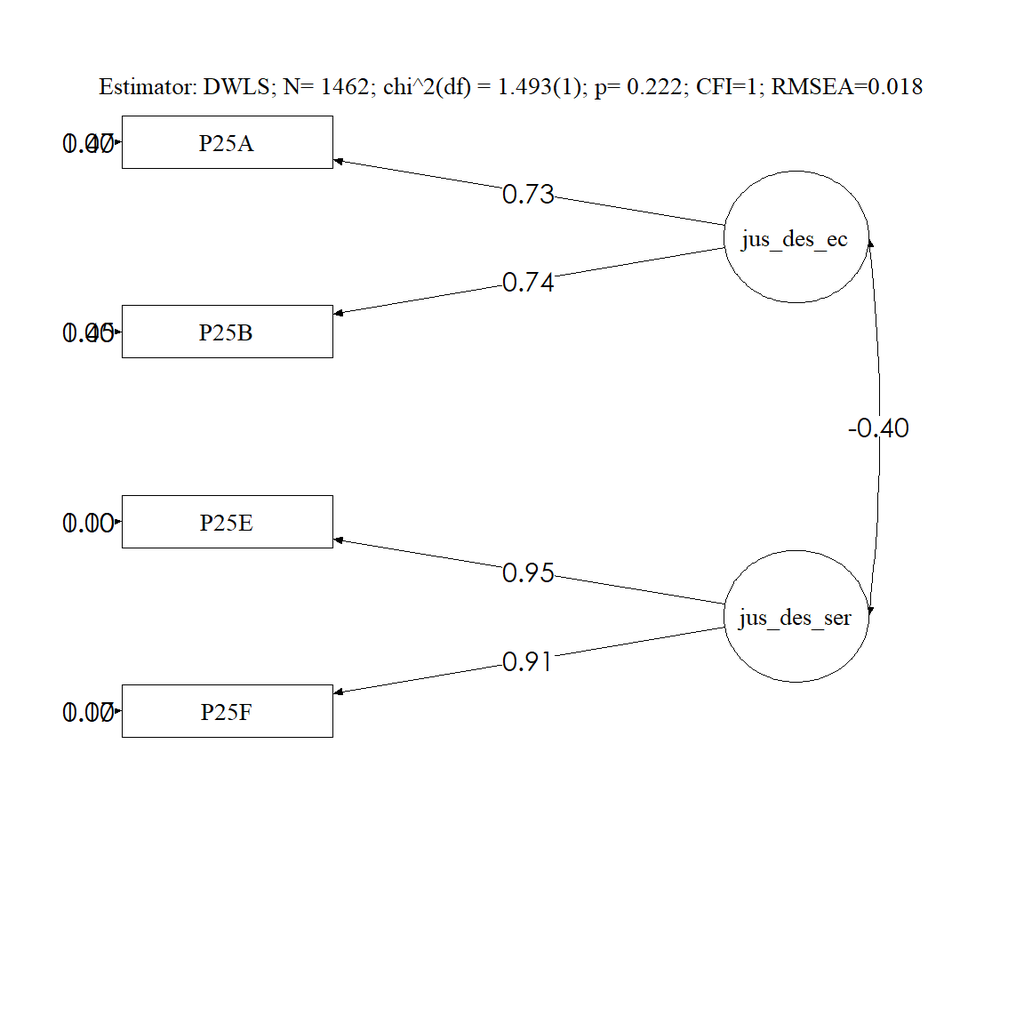

> Modelo completo

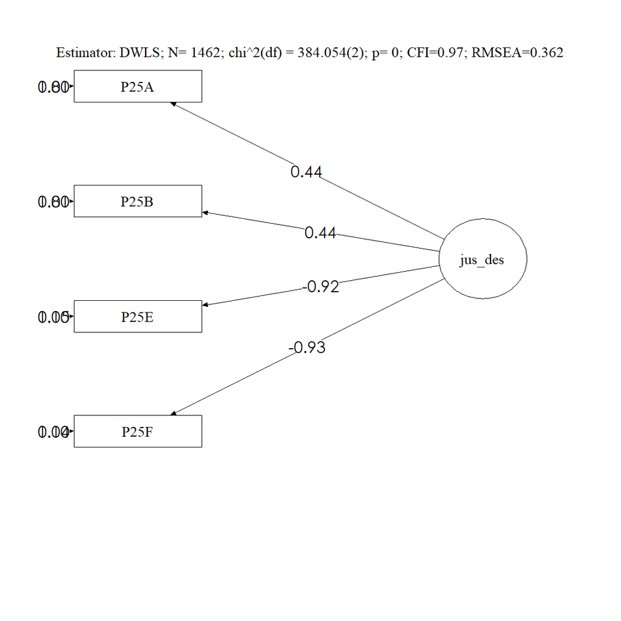

## Descriptivo

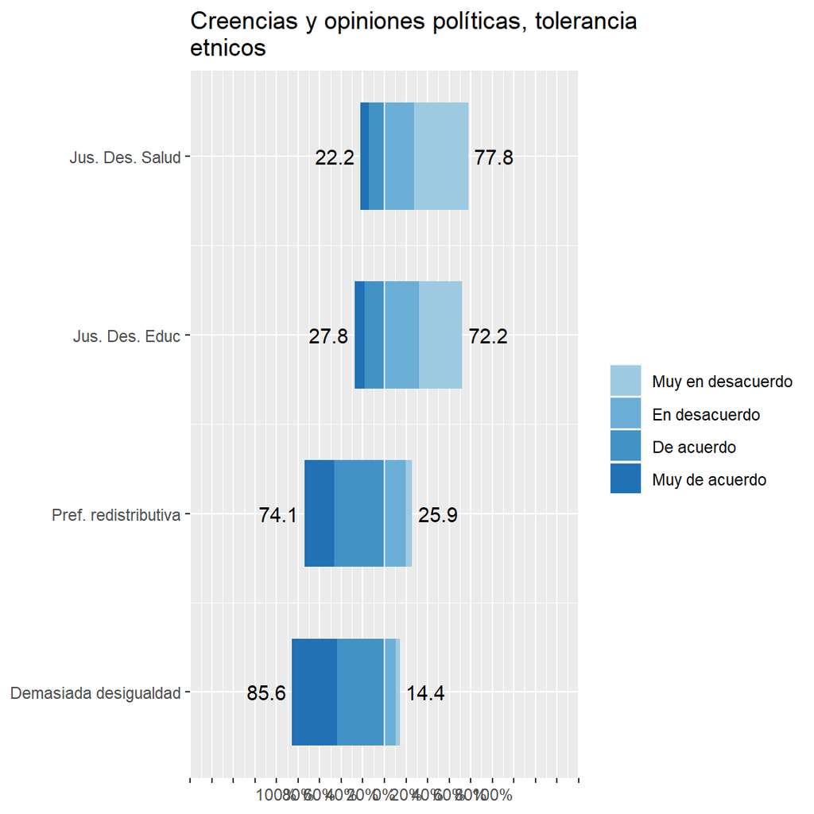

```r
#Descriptivos


#sjPlot::view_df(est_proc_inmigrantes, show.type = T, show.frq = T) # Cambiar por dfsummary
items <- c("Demasiada desigualdad", "Pref. redistributiva","Jus. Des. Educ","Jus. Des. Salud")

# cambiar orden para la leyenda
labels= c("Muy en desacuerdo",
"En desacuerdo",
"De acuerdo",
"Muy de acuerdo")


est_proc_legdesigual %>%  select(contains("A"),contains("B"),contains("E"),contains("F")) %>% sjPlot::plot_likert( axis.labels   = items,
                         legend.labels = labels,
                         legend.pos = "bottom",
                         #cat.neutral   = , # identifica a indiferentes
                         geom.colors   = c("#9ECAE1", "#6BAED6", "#4292C6",
                                           "#2171B5"), # colorbrewer2.org
                         sort.frq      = "neg.asc", # sort descending)
                         title         = "Creencias y opiniones políticas, tolerancia etnicos",
                         intercept.line.color = "white", # vertical middle
                         expand.grid   = F, # no inner margins in plot
                         show.n        = FALSE, # hide N's in axis labels
                         grid.range    = 1.8,
                         geom.size = 0.6, values = "sum.outside")
```

## Correlaciones

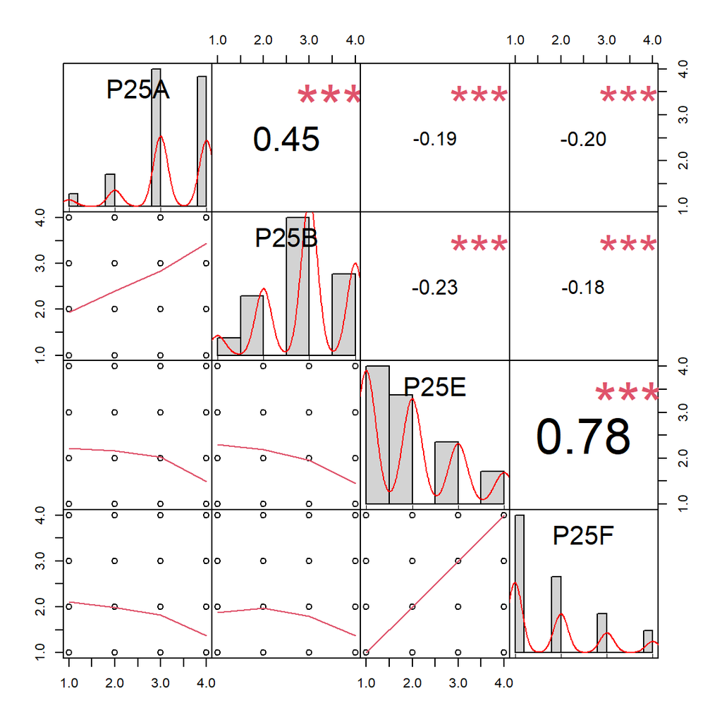

```r
# correlaciones


est_proc_legdesigual %>%  select(contains("A"),contains("B"),contains("E"),contains("F")) %>% chart.Correlation(histogram = TRUE, method = "pearson")
```

```r
# La variable P21B  y P21C no correlaciona bien con las demas.

#-----------------------------------------------------------------------------------------##
```

# Autoestima politico

La f y la a incorporan aspectos externos a la la comprensión y autoestipa para actuar. Por un lado la incorpora una compración con los compañeros y la f a temas coyunturales que bien pueden ser complejos en la situación actual.

```r
load(file="../input/data/original.RData")

pacman::p_load(dplyr, sjmisc, car, sjlabelled, stargazer, SciViews, summarytools, misty,sjPlot,PerformanceAnalytics,ggplot2,lavaan,stats, semPlot)

# Seleccionar y renombrar variables de la base de datos de estudiantes.
est_proc_autoritarismo <- est  %>% dplyr::select(starts_with("P47"))

est_proc_autoritarismo <- set_na(est_proc_autoritarismo, na = c(5,9), drop.levels = TRUE, as.tag = FALSE) # Transformar a NA

est_proc_autoritarismo =na.omit(est_proc_autoritarismo)
```

## Modelos

```r
# Exploratorio

#factanal(est_proc_autoritarismo, factors = 1, rotation = "none")

# AFC: Modelo con todos los indicadores



modeloautoritario1 =  ' autoestima =~ P47A + P47B + P47C + P47D +  P47E + P47F'

fit1 <- cfa(modeloautoritario1, data=est_proc_autoritarismo, estimator="DWLS", ordered = T)

#summary(fit1, fit.measures=TRUE)

#semPaths(fit1, what = "stand")

# AFC: Modelo con indicadores reducidos

modeloautoritario2 =  ' autoestima =~ P47E + P47B + P47C + P47D '

fit2 <- cfa(modeloautoritario2, data=est_proc_autoritarismo, estimator="DWLS", ordered = T)

#summary(fit2, fit.measures=TRUE)

#semPaths(fit2, what = "stand")

#modificationindices(fit2)
```

```r
#-----------------------------------------------------------------------------------------##
pacman::p_load(dplyr, kableExtra, knitr)

# extract fit indices from models and add to table
sum_fit1<- dplyr::bind_rows(fitmeasures(fit1)[c("chisq","df","pvalue","cfi","tli","rmsea","srmr")],
                    fitmeasures(fit2)[c("chisq","df","pvalue","cfi","tli","rmsea","srmr")])

# Customize object
sum_fit1$mod <- c("Todas las variables","Bateria recortada")
sum_fit1$nobs <- c(nobs(fit1),nobs(fit2))
sum_fit1$est <- c("DWLS","DWLS")
sum_fit1$df_ch<-c(sum_fit1$chisq/sum_fit1$df)
sum_fit1 <- dplyr::select(sum_fit1,mod,nobs,est,everything())
colnames <- c("Modelo","$N$","Estimador","$\\chi^2$","df","p-value","CFI","TLI","RMSEA","SRMR","$\\chi2$/df")

# Create table
table_cfa_fits1 <-kable(sum_fit1, format="pandoc", digits=3, booktabs=T, col.names=colnames,  caption = "Comperación entre modelos", escape = FALSE) %>% kable_styling(full_width = F, font_size = 14)
table_cfa_fits1
```

Comperación entre modelos

| Modelo | $N$ | Estimador | $\chi^2$ | df | p-value | CFI | TLI | RMSEA | SRMR | $\chi2$/df |
| --- | --- | --- | --- | --- | --- | --- | --- | --- | --- | --- |
| Todas las variables | 1507 | DWLS | 54.985 | 9 | 0.000 | 0.999 | 0.998 | 0.058 | 0.022 | 6.109 |
| Bateria recortada | 1507 | DWLS | 2.059 | 2 | 0.357 | 1.000 | 1.000 | 0.004 | 0.007 | 1.030 |

> Modelo reducido

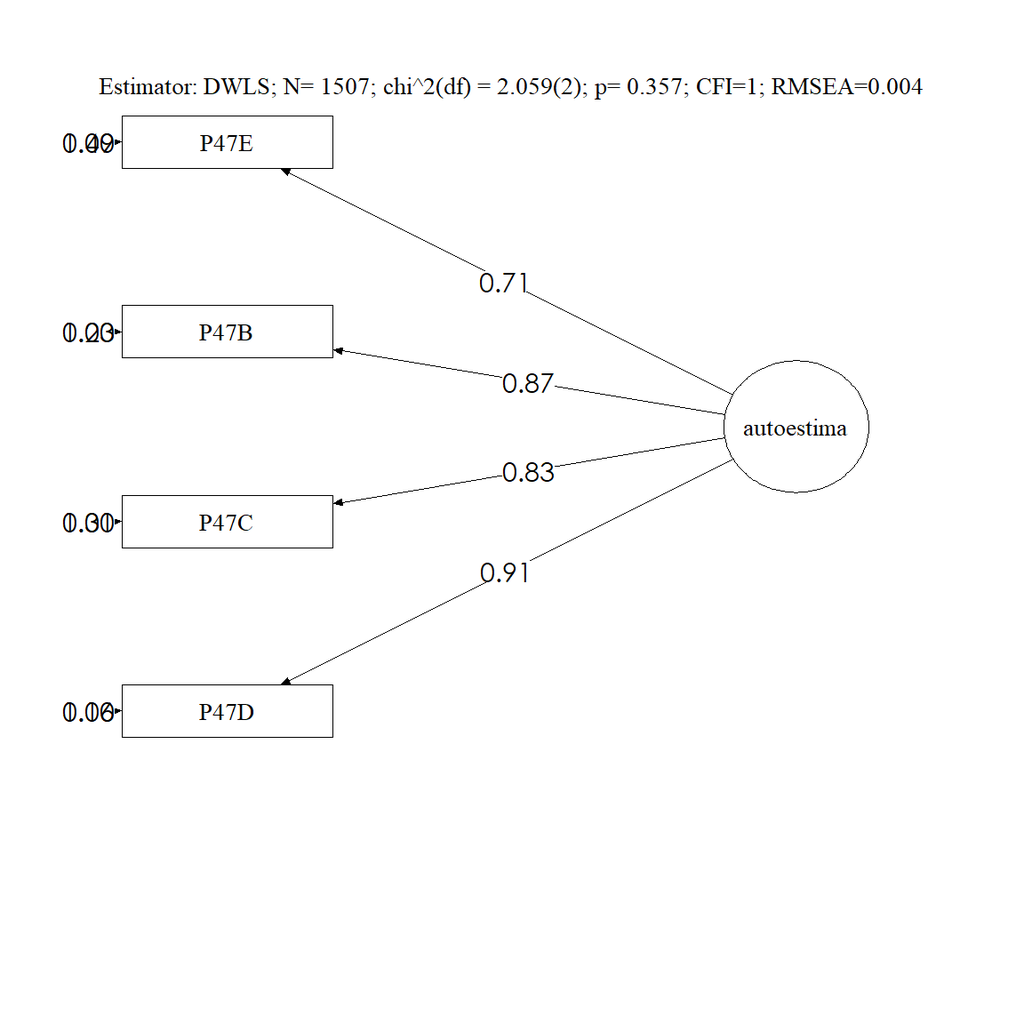

> Modelo completo

[figure not shown]